# p8105_hw3_yl4923

## Problem 1

1.1 data exploration There are *1384617* rows and *15* columns in the *instacart* data set. The key variables like *order_id*, *product_id* or *user_id* helps both customers and stores to identify products bought. For instant, in row 1, *user 112108* ordered *Bulgarian Yogurt (product 49302)* which was the first to be added to the cart and was also reordered by this user. This product was placed at *yogurt aisle (aisle_id 120)* in the *dairy & eggs department (department_id 16)*.The order was placed on Thursday between 10-11 am, 9 days after the user’s last purchase.

1.2 aisles

```r
instacart %>%
  group_by(aisle, aisle_id) %>%
  summarize(n = n()) %>%
  arrange(desc(n)) %>%
  tbl_df()
```

```
## # A tibble: 134 x 3
##    aisle                         aisle_id      n
##    <chr>                            <int>  <int>
##  1 fresh vegetables                    83 150609
##  2 fresh fruits                        24 150473
##  3 packaged vegetables fruits         123  78493
##  4 yogurt                             120  55240
##  5 packaged cheese                     21  41699
##  6 water seltzer sparkling water      115  36617
##  7 milk                                84  32644
##  8 chips pretzels                     107  31269
##  9 soy lactosefree                     91  26240
## 10 bread                              112  23635
## # ... with 124 more rows
```

There are *134* different aisles and most items ordered with a count of 150609 is from aisle *fresh vegetables* with id *83*.

1.3 plot aisles with more 10000 items ordered

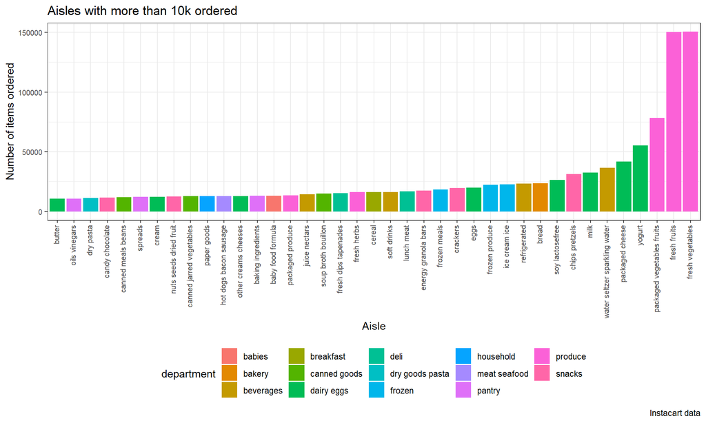

```r
instacart %>%
  group_by(aisle, department) %>%
  summarise(n = n()) %>%
  filter(n > 10000) %>%
  ggplot(aes(x = reorder(aisle, n), y = n, fill = department)) +
  geom_histogram(position = "dodge", stat = "identity") +
  labs(
    title = "Aisles with more than 10k ordered",
    x = "Aisle",
    y = "Number of items ordered",
    caption = "Instacart data") +
   theme(axis.text.x = element_text(angle = 90, vjust = 0.25, hjust = 1),
        axis.text = element_text(size = 7.5) )
```

The histogram shows the number of products in aisles with more than 10k orders as well as colored them which department falls in. Thus, we can tell these aisles by more general categories, which can be easier to find than through their long names.

```r
instacart %>%
  filter(aisle == c("baking ingredients", "dog food care", "packaged vegetables fruits")) %>%
  group_by(aisle, product_name) %>%
  summarize(order_number = n()) %>%
  filter(order_number == max(order_number)) %>%
  knitr::kable(caption = "Most popular items of the aisles “baking ingredients”, “dog food care”, and “packaged vegetables fruits” ", align = "lccrr")
```

Most popular items of the aisles “baking ingredients”, “dog food care”, and “packaged vegetables fruits”

| aisle | product_name | order_number |
| --- | --- | --- |
| baking ingredients | Light Brown Sugar | 157 |
| dog food care | Organix Grain Free Chicken & Vegetable Dog Food | 14 |
| packaged vegetables fruits | Organic Baby Spinach | 3324 |

1.5 a table showing the mean hour of the day at which Pink Lady Apples and Coffee Ice Cream are ordered on each day of the week

```r
instacart %>%
  filter(product_name %in% c("Pink Lady Apples", "Coffee Ice Cream")) %>%
  select(product_name, order_dow, order_hour_of_day) %>%
  group_by(product_name, order_dow) %>%
  summarize(mean_hour = mean(order_hour_of_day)) %>%
  mutate(order_dow_char = c("Sun", "Mon", "Tue", "Wed", "Thu", "Fri", "Sat")) %>%
  select(-order_dow) %>%
  pivot_wider(
    names_from = "order_dow_char",
    values_from = "mean_hour") %>%
  knitr::kable(digits = 2,
               caption = "Mean hour of each day at which Pink Lady Apples and Coffee Ice Cream are ordered",
               align = "lccrr")
```

Mean hour of each day at which Pink Lady Apples and Coffee Ice Cream are ordered

| product_name | Sun | Mon | Tue | Wed | Thu | Fri | Sat |
| --- | --- | --- | --- | --- | --- | --- | --- |
| Coffee Ice Cream | 13.77 | 14.32 | 15.38 | 15.32 | 15.22 | 12.26 | 13.83 |
| Pink Lady Apples | 13.44 | 11.36 | 11.70 | 14.25 | 11.55 | 12.78 | 11.94 |

### Problem 2

2.1 Data cleaning

```r
brfss_df =
  brfss_smart2010 %>%
  janitor::clean_names() %>%
  filter(topic == "Overall Health") %>%
  mutate(response = fct_relevel(response, c("Poor", "Fair", "Good", "Very good", "Excellent"))) %>%
  select(year,
         state = locationabbr,
         location = locationdesc,
         response,
         sample_size,
         data_value)
```

2.2 States observed at 7 or more locations in 2002 and 2010

```r
state_2002 =
  brfss_df %>%
  filter(year == 2002) %>%
  distinct(state, location) %>%
  count(state) %>%
  filter(n >= 7) %>%
  tbl_df

state_2010 =
  brfss_df %>%
  filter(year == 2010) %>%
  distinct(state, location) %>%
  count(state) %>%
  filter(n >= 7) %>%
  tbl_df
```

In 2002,*CT, FL, MA, NC, NJ, PA* were observed at 7 or more locations; in 2010, *CA, CO, FL, MA, MD, NC, NE, NJ, NY, OH, PA, SC, TX, WA* were observed at 7 or more locations.

2.2 Plot ‘Excellent’ response

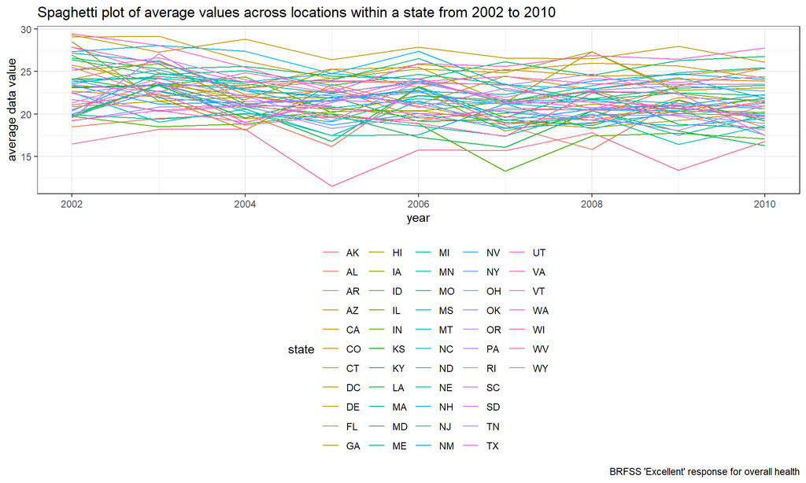

```r
brfss_df %>%
  filter(response == "Excellent") %>%
  select(year, state, data_value) %>%
  group_by(year, state) %>%
  summarize(ave_data = mean(data_value)) %>%
  ggplot(aes(x = year, y = ave_data, color = state)) +
  geom_line() +
  labs(
    title = "Spaghetti plot of average values across locations within a state from 2002 to 2010",
    y = "average data value",
    caption = "BRFSS 'Excellent' response for overall health")
```

Most of states appears a relatively constant average *data value* over the eight year period while state AK in red line is the one deviates the most in 2005 and 2009.

2.3 Plot 2006 and 2010 health responses in NY

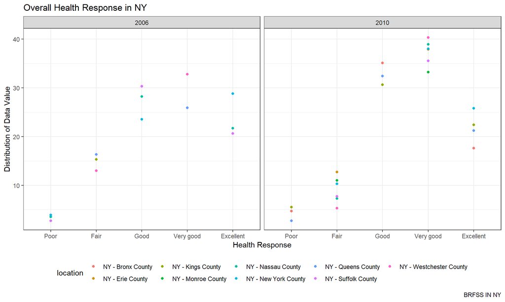

```r
brfss_df %>%
  filter(state == "NY", year == c("2006", "2010")) %>%
  select(year, location, response, data_value) %>%
  ggplot(aes(x = response, y = data_value, color = location)) +
  geom_point() +
  facet_grid(. ~ year) +
  labs(
    title = "Overall Health Response in NY",
    x = "Health Response",
    y = "Distribution of Data Value",
    caption = "BRFSS IN NY")
```

### Problem 3

3.1 data cleaning

```r
acc_df = read_csv("data/accel_data.csv") %>%
  janitor::clean_names() %>%
  pivot_longer(
    activity_1:activity_1440,
    names_to = "activity",
    names_prefix = "activity_",
    values_to = "n_act"
  ) %>%
  mutate(day_class = recode(day,
                            "Monday" = "weekday", "Tuesday" = "weekday", "Wednesday" = "weekday", "Thursday" = "weekday", "Friday" = "weekday", "Saturday" = "weekend", "Sunday" = "weekend"))
```

The resulting data set includes, *week*, *day_id*, *day* as well as *activity* and *n_act* derived from original *activity_1* to *activity_1440*. Also, a new variable *day_class* classified a *day* into weekday or weekend is added. We now have *50400* observations and *6* variables for this five weeks of accelerometer data.

3.2 total activity table for each day

```r
acc_df %>%
  group_by(week, day) %>%
  summarize(total_act = sum(n_act)) %>%
  mutate(day = c("Monday", "Tuesday", "Wednesday", "Thursday","Friday", "Saturday", "Sunday")) %>%
  select(week, day, total_act) %>%
  knitr::kable(caption = "Total physical activity of each day",
               align = "lccrr")
```

Total physical activity of each day

| week | day | total_act |
| --- | --- | --- |
| 1 | Monday | 480542.62 |
| 1 | Tuesday | 78828.07 |
| 1 | Wednesday | 376254.00 |
| 1 | Thursday | 631105.00 |
| 1 | Friday | 355923.64 |
| 1 | Saturday | 307094.24 |
| 1 | Sunday | 340115.01 |
| 2 | Monday | 568839.00 |
| 2 | Tuesday | 295431.00 |
| 2 | Wednesday | 607175.00 |
| 2 | Thursday | 422018.00 |
| 2 | Friday | 474048.00 |
| 2 | Saturday | 423245.00 |
| 2 | Sunday | 440962.00 |
| 3 | Monday | 467420.00 |
| 3 | Tuesday | 685910.00 |
| 3 | Wednesday | 382928.00 |
| 3 | Thursday | 467052.00 |
| 3 | Friday | 371230.00 |
| 3 | Saturday | 381507.00 |
| 3 | Sunday | 468869.00 |
| 4 | Monday | 154049.00 |
| 4 | Tuesday | 409450.00 |
| 4 | Wednesday | 1440.00 |
| 4 | Thursday | 260617.00 |
| 4 | Friday | 340291.00 |
| 4 | Saturday | 319568.00 |
| 4 | Sunday | 434460.00 |
| 5 | Monday | 620860.00 |
| 5 | Tuesday | 389080.00 |
| 5 | Wednesday | 1440.00 |
| 5 | Thursday | 138421.00 |
| 5 | Friday | 549658.00 |
| 5 | Saturday | 367824.00 |
| 5 | Sunday | 445366.00 |

3.3 24-hour activity time courses for each day

[figure not shown]

```r
acc_df %>%
  group_by(week, day) %>%
  ggplot(aes(x = activity, y = n_act, color = day)) +
  geom_line() +
  labs(
    title = "Daily Activity Over 5 Weeks",
    x = "Day of Week",
    y = "Total Activity",
    caption = "Accelerometer Data")
```